# MAESTRIA EN DATA MINING - TP AID

MARIA JOSE FERREYRA VILLANUEVA

Ago 2020

##### ASIGNACION DE BASES:

**SUPERVISADA** <- base accidentes, el 90% de los datos

##### ANALISIS SUPERVISADO: ACCIDENTES

Referencias de los atributos:

- grave: calidad del accidente 1(grave) 0(leve)
- edad.conductor: en años
- antiguedad: del vehículo en años
- potencia: potencia del vehículo

Seleccionamos los datos con los que vamos a trabajar utilizando la semilla pedida:

```r
# levantamos el dataset
datos <- read.csv("accidentes.csv", sep=";", stringsAsFactors = FALSE)

# tomamos el 90% de los datos segun la semilla asignada
dni<-23297670
n<-round(0.9* nrow(datos))
set.seed(dni)
cuales<-sample(1:nrow(datos), size=n, replace=FALSE)


df_accidentes<-datos[cuales,]
rm(datos)
```

##### ANALISIS EXPLORATORIO

Dimensiones y características del dataset:

```r
dim(df_accidentes)
```

```
## [1] 36  5
```

```r
summary(df_accidentes)
```

```
##     vehiculo       antigüedad     edad.conductor     potencia
##  Min.   : 1.00   Min.   : 1.000   Min.   :19.00   Min.   :  7.00
##  1st Qu.:10.75   1st Qu.: 2.000   1st Qu.:24.00   1st Qu.: 60.00
##  Median :20.00   Median : 5.000   Median :38.00   Median : 72.50
##  Mean   :20.14   Mean   : 5.889   Mean   :38.42   Mean   : 78.53
##  3rd Qu.:29.25   3rd Qu.:10.000   3rd Qu.:46.50   3rd Qu.: 90.00
##  Max.   :39.00   Max.   :15.000   Max.   :65.00   Max.   :130.00
##      grave
##  Min.   :0.0000
##  1st Qu.:0.0000
##  Median :0.0000
##  Mean   :0.4167
##  3rd Qu.:1.0000
##  Max.   :1.0000
```

```r
str(df_accidentes)
```

```
## 'data.frame':    36 obs. of  5 variables:
##  $ vehiculo      : int  23 39 24 16 7 25 27 1 26 36 ...
##  $ antigüedad    : int  15 12 12 10 10 5 1 6 5 4 ...
##  $ edad.conductor: int  59 63 63 23 23 65 38 21 46 42 ...
##  $ potencia      : int  60 70 70 130 130 110 60 75 60 60 ...
##  $ grave         : int  0 0 0 1 1 0 0 1 0 0 ...
```

- El atributo *vehiculo* es un identificador de registro. No se tomará en cuenta para el análisis.
- El atributo *grave* es nuestro atributo de clase.
- El resto de los atributos son numéricos y se utilizarán para la predicción de la clase.
- Contamos con un dataset de 36 observaciones

```r
# sacamos el atributo vehiculo
df_accidentes<-df_accidentes[,-c(1)]
```

Bucamos outliers univariados:

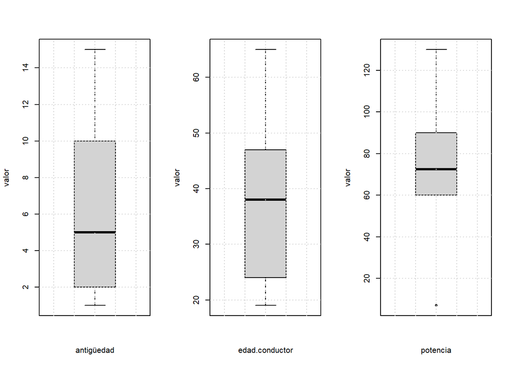

```r
# observamos los boxplot de las variables
par(mfcol = c(1,3))

for (col in 1:3){
  boxplot(df_accidentes[,col],
          xlab = names(df_accidentes)[col],
          ylab = "valor")
  grid()
}
```

En la variable *potencia* se observa un outlier.

```r
# hay un outlier en el atributo potencia, el resto de los valores
# del atributo (entre 60 y 130). Decido dejarlo afuera del analisis

df_accidentes <-df_accidentes[df_accidentes$potencia>=60,]
```

Buscamos outliers multivariados.

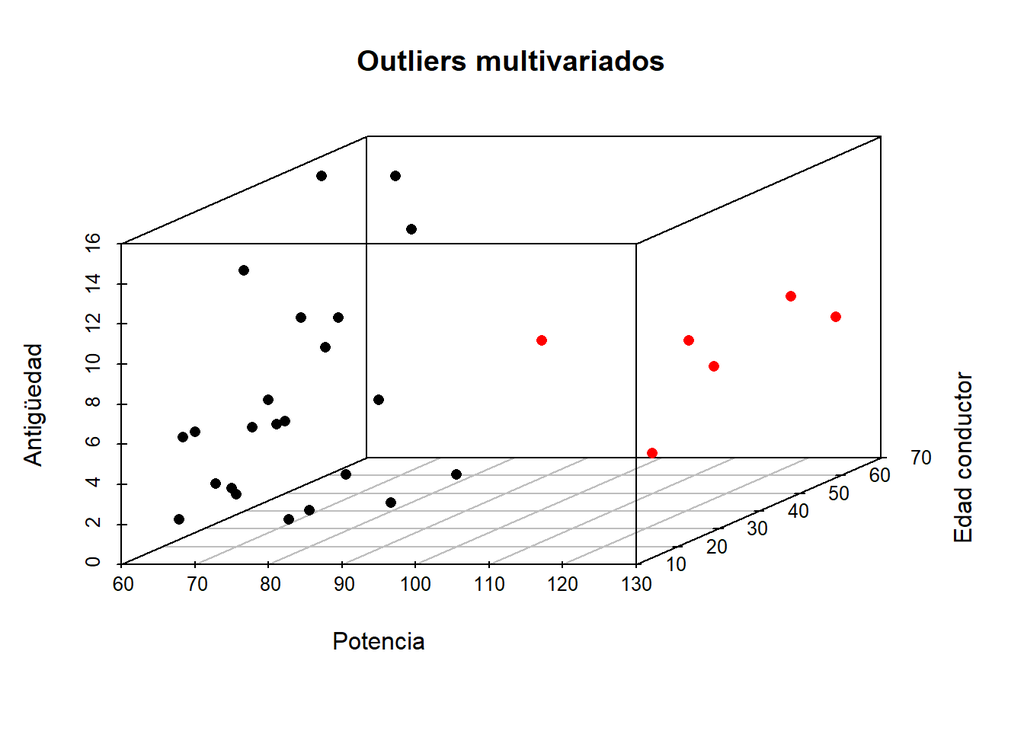

```r
# Aplicamos la distancia de mahalanobis y MCD (Minimum Covariance Determinant)
outliers <- df_accidentes[,1:3]

# metodo de MCD
cov.mcd=cov.rob( outliers, method="mcd" , nsamp="exact" )
outliers$mahalanobis <-round( mahalanobis(outliers, cov.mcd$center, cov.mcd$cov, inverted = F),4)

# Ordenamos de forma decreciente, según el score de Mahalanobis
outliers <- outliers[order(outliers$mahalanobis,decreasing = TRUE),]

# Descartamos los outliers según un umbral de 7
umbral<-7

outliers$outlier <- (outliers$mahalanobis>umbral)

outliers$color <- ifelse(outliers$outlier, "red", "black")

scatterplot3d(outliers$potencia,
              outliers$edad.conductor,
              outliers$antigüedad, color = outliers$color,
              main="Outliers multivariados",
              xlab = "Potencia",
              ylab = "Edad conductor",
              zlab = "Antigüedad",
              pch = 16)
```

Se encontraron 6 outliers multivariados.

##### ANALISIS UNIVARIADO

Relaciones entre las variables: Graficamos el dispersograma, distinguiendo la variable objetivo.

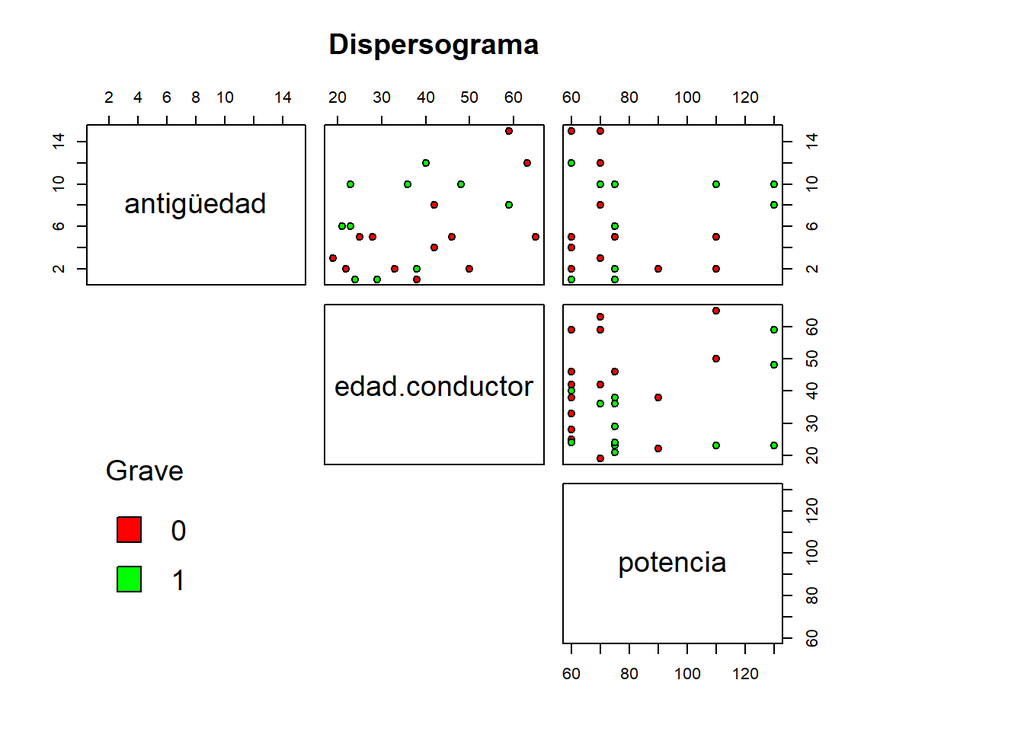

```r
pairs(df_accidentes[1:3], main="Dispersograma",
      lower.panel = NULL,
      pch=21, bg=c("red", "green")[as.factor(df_accidentes$grave)],
      oma=c(4, 4, 6, 12))
par(xpd=TRUE)
legend(x = 0.05, y = 0.4, cex = 1.2,unique(df_accidentes$grave), bty='n',
       fill=c("red",  "green"), title="Grave")
```

```r
par(xpd = NA)
```

Matriz de correlacion de Pearson.

```r
cor(df_accidentes[,1:3])
```

```
##                antigüedad edad.conductor  potencia
## antigüedad      1.0000000      0.3998323 0.1795235
## edad.conductor  0.3998323      1.0000000 0.1045572
## potencia        0.1795235      0.1045572 1.0000000
```

No se observa multicolinealidad entre las variables  
Histograma de las variables, identificando la clase objetivo.

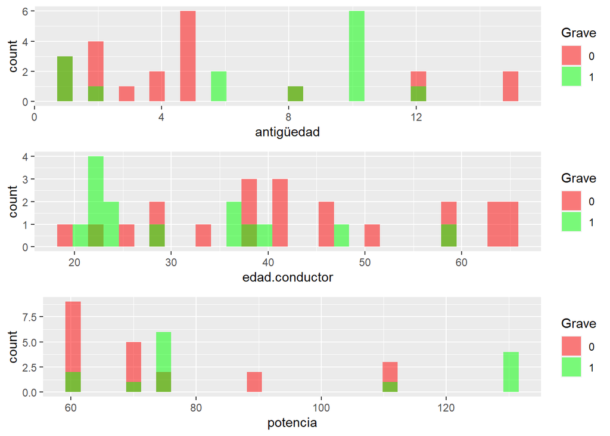

```r
p1<- ggplot(data = df_accidentes,aes(x = antigüedad, fill = as.factor(grave))) +
  geom_histogram(position = "identity", alpha = 0.5) + labs(fill = "Grave") +
  scale_fill_manual(values=c("red", "green"))

p2 <- ggplot(data = df_accidentes, aes(x = edad.conductor, fill = as.factor(grave))) +
  geom_histogram(position = "identity", alpha = 0.5) + labs(fill = "Grave") +
  scale_fill_manual(values=c("red", "green"))

p3 <- ggplot(data = df_accidentes, aes(x = potencia, fill = as.factor(grave))) +
  geom_histogram(position = "identity", alpha = 0.5) + labs(fill = "Grave") +
  scale_fill_manual(values=c("red", "green"))

grid.arrange(p1, p2, p3)
```

No se observan variables que sean buenas para discriminar las clases

Analizamos normalidad de distribuciones por clase. Observamos los graficos de cuantiles y hacemos test de Shapiro y Anderson

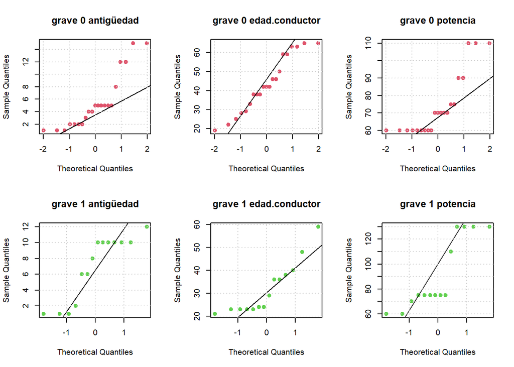

```r
# Representación de cuantiles normales de cada variable para cada clase
pvalSh = matrix(nrow=2, ncol=5)
pvalAd = matrix(nrow=2, ncol=5)
par(mfcol = c(2,3))
for (col in 1:3){
  pvalSh[1,4] = paste("Shapiro", "grave 0")
  pvalSh[2,4] = paste("Shapiro", "grave 1")
  pvalAd[1,4] = paste("Anderson", "grave 0")
  pvalAd[2,4] = paste("Anderson", "grave 1")

  for (grav in seq.int(0,1)){
    # p valor de shapiro
    pval = shapiro.test(df_accidentes[df_accidentes$grave==grav,col])$p.value
    pval2 = ad.test(df_accidentes[df_accidentes$grave==grav,col])$p.value
   qqnorm(df_accidentes[df_accidentes$grave==grav,col],main = paste("grave",grav,names(df_accidentes[col]))
          ,col=grav+2, pch = 19)
   qqline(df_accidentes[df_accidentes$grave==grav,col],col="black")
    pvalSh[grav+1,col] = round(pval,4)
    pvalAd[grav+1,col] = round(pval2,4)
    pvalSh[grav+1,5] = grav
    pvalAd[grav+1,5] = grav
    pvalSh[grav+1,4] = "Shapiro"
    pvalAd[grav+1,4] = "Anderson"

    grid()
  }

}
```

```r
# tabla de datos/tests / p-valor
df_pvalues <- rbind(as.data.frame(pvalSh),as.data.frame(pvalAd))
colnames(df_pvalues)[1:3]<-names(df_accidentes[1:3])
colnames(df_pvalues)[4]<-"Test"
colnames(df_pvalues)[5]<-"Grave"
df_pvalues
```

```
##   antigüedad edad.conductor potencia     Test Grave
## 1     0.0013         0.2109    1e-04  Shapiro     0
## 2     0.0082         0.0155   0.0019  Shapiro     1
## 3      5e-04         0.3155        0 Anderson     0
## 4     0.0039         0.0151    4e-04 Anderson     1
```

Exploramos los histogramas por clase:

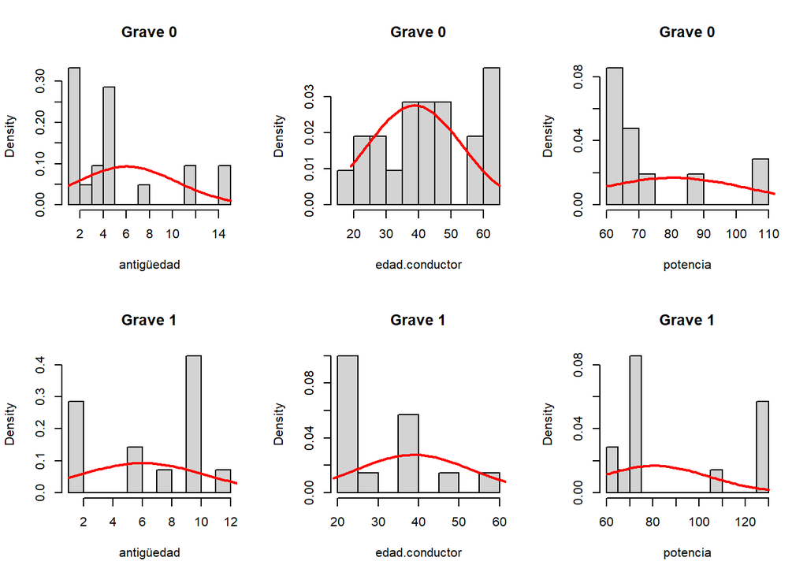

```r
#histogramas de las variables y su normalidad
par(mfcol = c(2,3))

for (col in 1:3)
{
  for (grav in seq.int(0,1))
    {
      hist(df_accidentes[df_accidentes$grave==grav,col],proba = T,
           xlab = names(df_accidentes)[col],10,main=paste("Grave",grav))
      x0 <- seq(min(df_accidentes[, col]), max(df_accidentes[, col]), le = 50)
      lines(x0, dnorm(x0, mean(df_accidentes[,col]), sd(df_accidentes[,col])), col = "red", lwd = 2)

    }
}
```

##### ANALISIS MULTIVARIADO

Comparamos las medias de los grupos con el test de Hotelling y graficamos de perfiles

```r
# El test de hotelling compara las medias multivariadas entre los dos grupos

HotellingsT2Test(as.matrix(df_accidentes[,1:3]) ~ grave, data =df_accidentes)
```

```
##
##  Hotelling's two sample T2-test
##
## data:  as.matrix(df_accidentes[, 1:3]) by grave
## T.2 = 7.1541, df1 = 3, df2 = 31, p-value = 0.0008714
## alternative hypothesis: true location difference is not equal to c(0,0,0)
```

El p-valor del test nos dice que tenemos evidencia para rechazar la hipotesis de que las medias de ambos grupos son iguales, por lo tanto vale la pena identificar los grupos con algun algoritmo clasificador…  
Grafico de perfiles

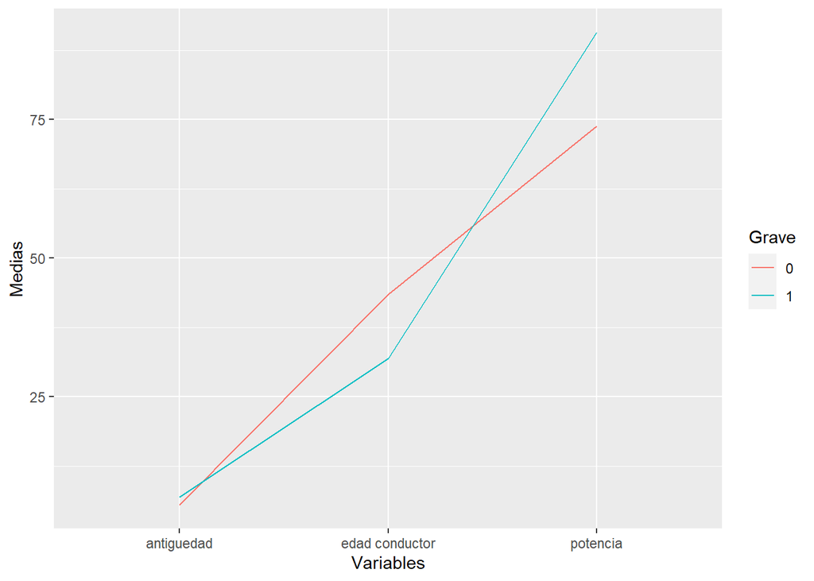

```r
#grafico de comparacion de vector de medias

media.grave0=apply(df_accidentes[df_accidentes$grave==0,1:3],2,mean)
media.grave1=apply(df_accidentes[df_accidentes$grave==1,1:3],2,mean)

ms=as.matrix(media.grave0)
mv=as.matrix(media.grave1)
medias=rbind(ms,mv)

datos=cbind(rep(c(1,2,3),2),medias,c(rep("0",3),rep("1",3)))
colnames(datos)=c("Variables","Medias","Grave")
data=data.frame(datos)

data[,1:2]=as.numeric(unlist(data[,1:2]))

ggplot(data,aes(x=Variables,y=Medias,colour=Grave))+ geom_line()+
  scale_x_discrete(limit=c("1","2","3"), labels=c("antiguedad","edad conductor","potencia"))
```

Se puede observar que los perfiles no son paralelos y las lineas de los grupos se cruzan.

##### ANALISIS DE SUPUESTOS

Testeamos supuestos de:

- Normalidad multivariada
- Homocedasticidad multivariada

```r
# testeamos normalidad multivariante

mshapiro.test(t(df_accidentes[df_accidentes$grave==0,1:3]))
```

```
##
##  Shapiro-Wilk normality test
##
## data:  Z
## W = 0.89951, p-value = 0.03424
```

```r
mshapiro.test(t(df_accidentes[df_accidentes$grave==1,1:3]))
```

```
##
##  Shapiro-Wilk normality test
##
## data:  Z
## W = 0.77808, p-value = 0.002708
```

Se rechaza la hipotesis de normalidad para ambos grupos  
Testeamos homocedasticidad mutivariante con el test M de box

```r
boxM(data =  df_accidentes[,1:3], grouping =  df_accidentes[,4])
```

```
##
##  Box's M-test for Homogeneity of Covariance Matrices
##
## data:  df_accidentes[, 1:3]
## Chi-Sq (approx.) = 13.821, df = 6, p-value = 0.0317
```

Se rechaza la hipotesis nula con un p-valor menor a 0.05  
Ante la sensibilidad del test M de box a la falta de normalidad, se realiza la alternativa robusta con la prueba de Levene multivarada para probar homocedasticidad.

```r
# alternativa robusta para probar la homocedasticidad

df_tot <- df_accidentes
df_tot$grave<- as.factor(df_tot$grave)

leveneTest (antigüedad + edad.conductor + potencia ~ grave,data= df_tot )
```

```
## Levene's Test for Homogeneity of Variance (center = median)
##       Df F value Pr(>F)
## group  1  0.2672 0.6087
##       33
```

No tenemos evidencia para rechazar la hipotesis nula que indica homocedasticidad.  
Analizamos la matriz de correlación por grupos.

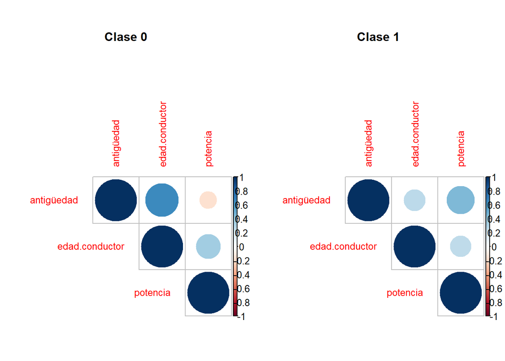

```r
cor.0 <-cor(df_accidentes[df_accidentes$grave==0,1:3])
cor.1 <- cor(df_accidentes[df_accidentes$grave==1,1:3])


par(mfcol = c(1,2))
corrplot(cor.0, type="upper", main="Clase 0",tl.cex = 0.8,cex.main=1,mar=c(0,0,5,0), tl.offset = 1)
corrplot(cor.1, type="upper", main="Clase 1",tl.cex = 0.8,cex.main=1,mar=c(0,0,5,0), tl.offset = 1)
```

##### ALGORITMOS SUPERVISADOS

Aplicaremos:

- Analisis Discriminante Lineal
- Analisis Discriminante Cuadrático Robusto
- Regresión Logística
- Maquina de Soporte Vectorial
- RandomForest

Balance de las clases:

```r
table(df_accidentes$grave)/nrow(df_accidentes)
```

```
##
##   0   1
## 0.6 0.4
```

Dividimos los conjuntos de entrenamiento y validacion:

```r
# dividimos los grupos de entrenamiento y validacion
# partimos en train y val, en 70 y 30 respectivamente
set.seed(4321)
train_index <- createDataPartition(as.factor(df_accidentes$grave), p = .7,
                                  list = FALSE,
                                  times = 1)

val_index <- setdiff(1:nrow(df_accidentes), train_index)

datos_train <- df_accidentes[train_index,]
datos_val <- df_accidentes[val_index,]

datos_todos <- df_accidentes

# inicializo los dataframes para guardar los resultados
res.acc<- data.frame("Validation" = c(0,0,0,0,0), "LOO" = c(0,0,0,0,0))
rownames(res.acc)<-c('LDA','QDAR','LG','SVM','RF')

res.rec <- res.acc
```

Aplicamos Analisis Lineal Discriminante (LDA)  
En cada algoritmo, usamos las tecnicas de entrenamiento y validacion y leave-one-out (loo)

```r
# algoritmo LDA con los dos metodos de particion

# train y val
modelo_lda <- lda(formula = grave ~ antigüedad + edad.conductor + potencia,
                 data = datos_train)

modelo_lda
```

```
## Call:
## lda(grave ~ antigüedad + edad.conductor + potencia, data = datos_train)
##
## Prior probabilities of groups:
##   0   1
## 0.6 0.4
##
## Group means:
##   antigüedad edad.conductor potencia
## 0   4.466667           42.8     76.0
## 1   6.300000           29.8     87.5
##
## Coefficients of linear discriminants:
##                        LD1
## antigüedad      0.15107484
## edad.conductor -0.09125883
## potencia        0.03326354
```

```r
predic_val_lda <- predict(object = modelo_lda, newdata = datos_val[1:3], method = "predictive")

cm_2<-confusionMatrix(predic_val_lda$class,as.factor(datos_val$grave), positive = '1')
cm_2$table
```

```
##           Reference
## Prediction 0 1
##          0 5 2
##          1 1 2
```

```r
res.acc["LDA","Validation"]<-cm_2$overall[1]
res.rec["LDA","Validation"]<-cm_2$byClass[6]

# loo
modelo_lda <- lda(formula = grave ~ antigüedad + edad.conductor + potencia,
                 data = datos_todos,CV=TRUE)

cm_3<-confusionMatrix(modelo_lda$class,as.factor(datos_todos$grave), positive = '1')

cm_3$table
```

```
##           Reference
## Prediction  0  1
##          0 18  6
##          1  3  8
```

```r
res.acc["LDA","LOO"]<-cm_3$overall[1]
res.rec["LDA","LOO"]<-cm_3$byClass[6]
```

Arriba se muestran las matrices de confusion de ambos modelos

Aplicamos Analisis Cuadrático Discriminante Robusto (QDAR)

```r
# train y val
modelo_qda <- QdaCov(as.factor(grave) ~ ., data= datos_train)
predic_val_qda <- predict(modelo_qda, newdata = datos_val[1:3])@classification
modelo_qda
```

```
## Call:
## QdaCov(as.factor(grave) ~ ., data = datos_train)
##
## Prior Probabilities of Groups:
##   0   1
## 0.6 0.4
##
## Group means:
##   antigüedad edad.conductor potencia
## 0        3.5       45.60000 81.00000
## 1        5.0       23.85714 85.71429
##
## Group:  0
##                antigüedad edad.conductor    potencia
## antigüedad       6.178976       33.22916    4.119318
## edad.conductor  33.229161      354.37116  463.835154
## potencia         4.119318      463.83515 1219.317989
##
## Group:  1
##                antigüedad edad.conductor   potencia
## antigüedad       42.34285      -14.39657  215.94854
## edad.conductor  -14.39657       15.60637  -33.57183
## potencia        215.94854      -33.57183 1554.58756
```

```r
cm_2<-confusionMatrix(predic_val_qda,as.factor(datos_val$grave), positive = '1')
cm_2$table
```

```
##           Reference
## Prediction 0 1
##          0 4 1
##          1 2 3
```

```r
res.acc["QDAR","Validation"]<-cm_2$overall[1]
res.rec["QDAR","Validation"]<-cm_2$byClass[6]

#LOO
modelo_qda <- qda(as.factor(grave) ~
                  antigüedad + edad.conductor + potencia , data = datos_todos,CV=TRUE)

cm_3<-confusionMatrix(modelo_qda$class,as.factor(datos_todos$grave), positive = '1')
cm_3$table
```

```
##           Reference
## Prediction  0  1
##          0 19  7
##          1  2  7
```

```r
res.acc["QDAR","LOO"]<-cm_3$overall[1]
res.rec["QDAR","LOO"]<-cm_3$byClass[6]
```

Arriba se muestran las matrices de confusion de ambos modelos

Aplicamos Regresion logística (LG)

```r
# train y val
modelo_lg <- glm(as.factor(grave) ~
                  antigüedad + edad.conductor + potencia , data = datos_train,family=binomial("logit"))

modelo_lga<-modelo_lg
summary(modelo_lg)
```

```
##
## Call:
## glm(formula = as.factor(grave) ~ antigüedad + edad.conductor +
##     potencia, family = binomial("logit"), data = datos_train)
##
## Deviance Residuals:
##     Min       1Q   Median       3Q      Max
## -2.1306  -0.3414  -0.1567   0.3090   1.6781
##
## Coefficients:
##                Estimate Std. Error z value Pr(>|z|)
## (Intercept)    -2.49265    2.77902  -0.897   0.3697
## antigüedad      0.42826    0.22573   1.897   0.0578 .
## edad.conductor -0.25283    0.10959  -2.307   0.0211 *
## potencia        0.11675    0.05757   2.028   0.0426 *
## ---
## Signif. codes:  0 '***' 0.001 '**' 0.01 '*' 0.05 '.' 0.1 ' ' 1
##
## (Dispersion parameter for binomial family taken to be 1)
##
##     Null deviance: 33.651  on 24  degrees of freedom
## Residual deviance: 16.066  on 21  degrees of freedom
## AIC: 24.066
##
## Number of Fisher Scoring iterations: 6
```

```r
predic_val_lg<-predict(modelo_lg,newdata = datos_val[1:3],type = "response")
clase_lg_val  = ifelse(predic_val_lg>0.5,1,0)

cm_2<-confusionMatrix(as.factor(clase_lg_val),as.factor(datos_val$grave), positive = '1')
cm_2$table
```

```
##           Reference
## Prediction 0 1
##          0 4 2
##          1 2 2
```

```r
res.acc["LG","Validation"]<-cm_2$overall[1]
res.rec["LG","Validation"]<-cm_2$byClass[6]


# LOO
glm.LOO=vector()

for(i in 1:nrow(datos_todos)){
  datos_train2=datos_todos[-i,]
  modelo_lg <- glm(as.factor(grave) ~
                  antigüedad + edad.conductor + potencia , data = datos_train2,family=binomial)
  glm.LOO[i]=predict(modelo_lg,datos_todos[i,1:3],type="response")
}

clase_lg  = ifelse(glm.LOO>0.5,1,0)
cm_3<-confusionMatrix(as.factor(clase_lg),as.factor(datos_todos$grave), positive = '1')

cm_3$table
```

```
##           Reference
## Prediction  0  1
##          0 18  6
##          1  3  8
```

```r
res.acc["LG","LOO"]<-cm_3$overall[1]
res.rec["LG","LOO"]<-cm_3$byClass[6]
```

Arriba se muestran los coeficientes del modelo de regresion y las matrices de confusion de ambos modelos

Test Hosmer - Lemeshow para el algoritmo de regresion logistica. Queremos verificar si el modelo se ajusta correctamente a los datos.

```r
predic_val_lg2<-predict(modelo_lga,newdata = datos_train[1:3],type = "response")

hoslem.test(predic_val_lg2, fitted(modelo_lga))
```

```
##
##  Hosmer and Lemeshow goodness of fit (GOF) test
##
## data:  predic_val_lg2, fitted(modelo_lga)
## X-squared = 0, df = 8, p-value = 1
```

El p valor es 1, por lo tanto no tenemos evidencia para rechazar la hipotesis nula que sostiene que el modelo se ajusta a los datos

Aplicamos Maquina de Soporte Vectorial (SVM)

```r
#train y validation

modelo_svm<-svm(as.factor(grave)~antigüedad + edad.conductor + potencia,
               data=datos_train,method="C-classification",kernel="radial",cost=10,gamma=.1, scale=TRUE)

predic_val_svm<-predict(modelo_svm,newdata = datos_val[1:3])

summary(modelo_svm)
```

```
##
## Call:
## svm(formula = as.factor(grave) ~ antigüedad + edad.conductor + potencia,
##     data = datos_train, method = "C-classification", kernel = "radial",
##     cost = 10, gamma = 0.1, scale = TRUE)
##
##
## Parameters:
##    SVM-Type:  C-classification
##  SVM-Kernel:  radial
##        cost:  10
##
## Number of Support Vectors:  15
##
##  ( 7 8 )
##
##
## Number of Classes:  2
##
## Levels:
##  0 1
```

```r
cm_2<-confusionMatrix(as.factor(predic_val_svm),as.factor(datos_val$grave), positive = '1')
cm_2$table
```

```
##           Reference
## Prediction 0 1
##          0 4 1
##          1 2 3
```

```r
res.acc["SVM","Validation"]<-cm_2$overall[1]
res.rec["SVM","Validation"]<-cm_2$byClass[6]


# LOO
svm.LOO=vector()


for(i in 1:nrow(datos_todos)){
  datos_train2=datos_todos[-i,]

  modelo_svm <- svm(as.factor(grave)~antigüedad + edad.conductor + potencia,
               data=datos_train2,method="C-classification",kernel="radial",cost=10,gamma=.1)

  svm.LOO[i]<-as.character(predict(modelo_svm,newdata =datos_todos[i,1:3]))

}

cm_3<-confusionMatrix(as.factor(svm.LOO),as.factor(datos_todos$grave), positive = '1')

cm_3$table
```

```
##           Reference
## Prediction  0  1
##          0 16  6
##          1  5  8
```

```r
res.acc["SVM","LOO"]<-cm_3$overall[1]
res.rec["SVM","LOO"]<-cm_3$byClass[6]
```

Arriba se muestran las matrices de confusion de ambos modelos  
Aplicamos Random Forest (RF)

```r
# train y val

modelo_rf<-randomForest(as.factor(grave)~antigüedad + edad.conductor + potencia, data=datos_train,
                       na.action = na.omit,replace=TRUE, ntree=700, maxnodes=10)

predic_val_rf<-predict(modelo_rf,newdata = datos_val[1:3])
cm_2<-confusionMatrix(as.factor(predic_val_rf),as.factor(datos_val$grave), positive = '1')
cm_2$table
```

```
##           Reference
## Prediction 0 1
##          0 5 2
##          1 1 2
```

```r
res.acc["RF","Validation"]<-cm_2$overall[1]
res.rec["RF","Validation"]<-cm_2$byClass[6]


# LOO
rf.LOO=vector()

for(i in 1:nrow(datos_todos)){
  datos_train2=datos_todos[-i,]
  modelo_rf<-randomForest(as.factor(grave)~antigüedad + edad.conductor + potencia, data=datos_train2,
                       na.action = na.omit,replace=TRUE, ntree=700)

  rf.LOO[i]<-as.character(predict(modelo_rf,newdata = datos_todos[i,1:3]))

}

cm_3<-confusionMatrix(as.factor(rf.LOO),as.factor(datos_todos$grave), positive = '1')
cm_3$table
```

```
##           Reference
## Prediction  0  1
##          0 16  4
##          1  5 10
```

```r
res.acc["RF","LOO"]<-cm_3$overall[1]
res.rec["RF","LOO"]<-cm_3$byClass[6]
```

Arriba se muestran las matrices de confusion de ambos modelos

##### COMPARAMOS PERFORMANCE DE TODOS LOS MODELOS

Analizamos la performance de los algoritmos con las metricas de Accuracy y Recall.

```r
# comparacion de accuracy de todos los modelos
round(res.acc,2)
```

```
##      Validation  LOO
## LDA         0.7 0.74
## QDAR        0.7 0.74
## LG          0.6 0.74
## SVM         0.7 0.69
## RF          0.7 0.74
```

```r
# comparacion de recall de todos los modelos
round(res.rec,2)
```

```
##      Validation  LOO
## LDA        0.50 0.57
## QDAR       0.75 0.50
## LG         0.50 0.57
## SVM        0.75 0.57
## RF         0.50 0.71
```

###### Maria Jose Ferreyra V. Agosto 2020